# K-Means

# Tarea 4.

# Ejercicios

Librerias

```r
library('ggplot2')
library('dplyr')
library('GGally')
library('reshape2')
library('corrr')
```

1. Desarolle el Análisis del Problema

Nos brindan informacion con respecto gasto anual en diferentes tipos de producto, por distintos canales y regiones. Vamos a realizar una exploracion de los datos para analizar que implicaciones tienen los mismos y determinar si hay correlaciones importantes, si existen grupos o cuales grupos existen y proveer informacion valiosa a los interesados.

Informacion de los atributos

m.u.: Moneda

1. FRESH: Gasto anual (m.u.) en productos frescos
2. MILK: Gasto anual (m.u.) en productos lacteos
3. GROCERY: Gasto anual (m.u.) en productos abarrotes
4. FROZEN: Gasto anual (m.u.) en productos congelados
5. DETERGENTS_PAPER: Gasto anual (m.u.) en productos de baño
6. DELICATESSEN: Gasto anual (m.u.) en productos embutidos
7. CHANNEL: Canal - Horeca (Hotel/Restaurant/Cafe) o Retail
8. REGION: Region - Lisboa, Oporto o Otros

Fuente del dataset: https://archive.ics.uci.edu/ml/datasets/Wholesale+customers

2. Cargue el archivo Wholesale customers data.csv en una variable

```r
data <- read.csv('wholesale.csv', header = T, na.strings = '?')
```

3. Desarolle el Entendimiento de los Datos

```r
glimpse(data)
```

```
## Observations: 440
## Variables: 8
## $ Channel          <int> 2, 2, 2, 1, 2, 2, 2, 2, 1, 2, 2, 2, 2, 2, 2, ...
## $ Region           <int> 3, 3, 3, 3, 3, 3, 3, 3, 3, 3, 3, 3, 3, 3, 3, ...
## $ Fresh            <int> 12669, 7057, 6353, 13265, 22615, 9413, 12126,...
## $ Milk             <int> 9656, 9810, 8808, 1196, 5410, 8259, 3199, 495...
## $ Grocery          <int> 7561, 9568, 7684, 4221, 7198, 5126, 6975, 942...
## $ Frozen           <int> 214, 1762, 2405, 6404, 3915, 666, 480, 1669, ...
## $ Detergents_Paper <int> 2674, 3293, 3516, 507, 1777, 1795, 3140, 3321...
## $ Delicassen       <int> 1338, 1776, 7844, 1788, 5185, 1451, 545, 2566...
```

```r
table(data$Channel)
```

```
##
##   1   2
## 298 142
```

```r
table(data$Region)
```

```
##
##   1   2   3
##  77  47 316
```

```r
# Debido al tipo de datos que representa estos atributos deben ser valores
data$Channel <- factor(data$Channel)
data$Region <- factor(data$Region)

summary(data)
```

```
##  Channel Region      Fresh             Milk          Grocery
##  1:298   1: 77   Min.   :     3   Min.   :   55   Min.   :    3
##  2:142   2: 47   1st Qu.:  3128   1st Qu.: 1533   1st Qu.: 2153
##          3:316   Median :  8504   Median : 3627   Median : 4756
##                  Mean   : 12000   Mean   : 5796   Mean   : 7951
##                  3rd Qu.: 16934   3rd Qu.: 7190   3rd Qu.:10656
##                  Max.   :112151   Max.   :73498   Max.   :92780
##      Frozen        Detergents_Paper    Delicassen
##  Min.   :   25.0   Min.   :    3.0   Min.   :    3.0
##  1st Qu.:  742.2   1st Qu.:  256.8   1st Qu.:  408.2
##  Median : 1526.0   Median :  816.5   Median :  965.5
##  Mean   : 3071.9   Mean   : 2881.5   Mean   : 1524.9
##  3rd Qu.: 3554.2   3rd Qu.: 3922.0   3rd Qu.: 1820.2
##  Max.   :60869.0   Max.   :40827.0   Max.   :47943.0
```

4. Utilizando barplot cree un gráfico de los atributos del dataset, observe las correlaciones entre atributos

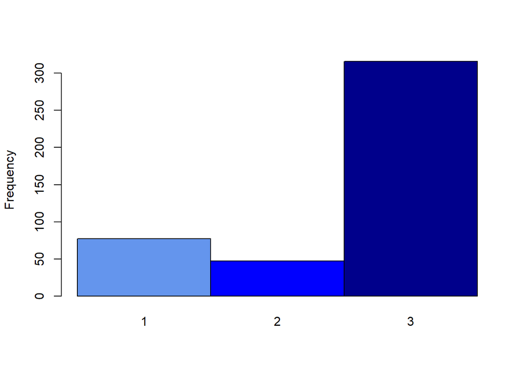

```r
barplot(table(data$Region), col=c("cornflowerblue", "blue","darkblue"), space=F, ylab="Frequency")
```

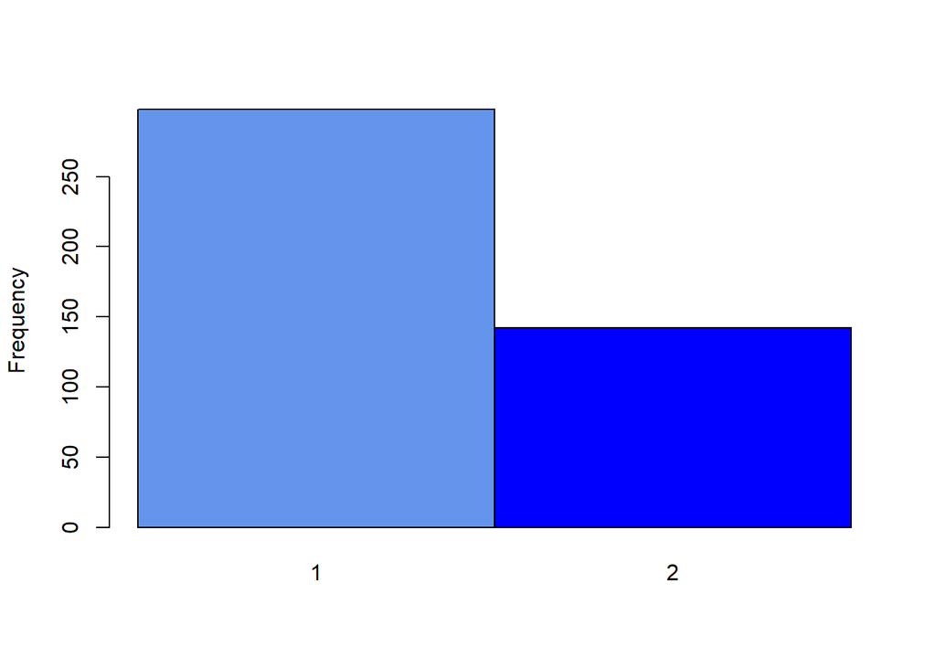

```r
barplot(table(data$Channel), col=c("cornflowerblue", "blue"), space=F, ylab="Frequency")
```

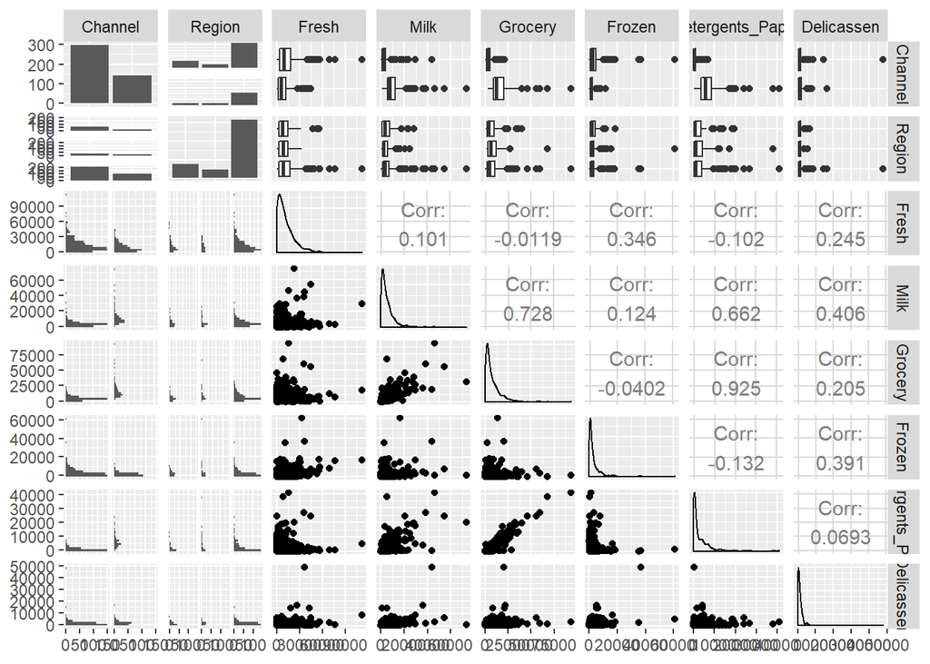

```r
ggpairs(data)
```

```
##
## Correlation method: 'pearson'
## Missing treated using: 'pairwise.complete.obs'
```

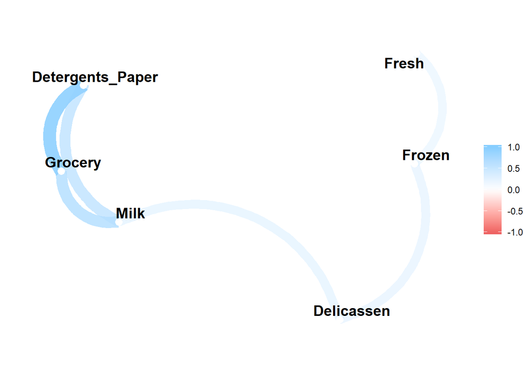

```r
data[3:8] %>% correlate() %>% network_plot()
```

5. Explique el siguiente gráfico

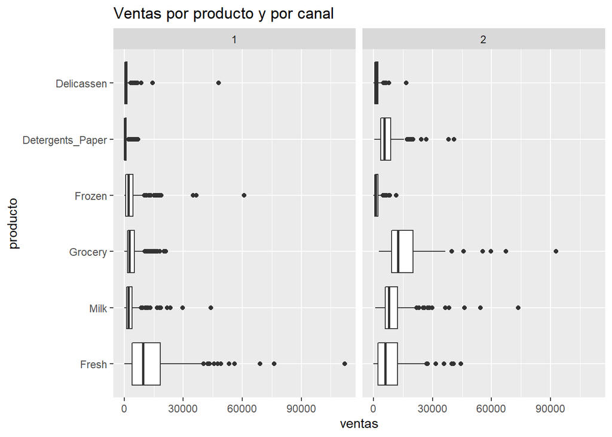

```r
#Grafico
bxplt <- ggplot(data = melt(data), aes(x= variable, y = value))
bxplt <- bxplt + geom_boxplot()
bxplt <- bxplt + facet_wrap(~Channel)
bxplt <- bxplt + coord_flip()
bxplt <- bxplt + labs(x = 'producto', y  = 'ventas')
bxplt <- bxplt + ggtitle('Ventas por producto y por canal')
bxplt
```